# How well you do barbell lifts?: prediction using data from accelerometers

Alfonso Buitrago

July 6th - 2020

## Summary

Devices such as Jawbone Up, Nike FuelBand, and Fitbit are used by people to collect large amounts of data about personal activity. These type of devices are part of the quantified self movement – a group of enthusiasts who take measurements about themselves regularly to improve their health, to find patterns in their behavior, or because they are tech geeks. One thing that people regularly do is quantify how much of a particular activity they do, but they rarely quantify how well they do it. This project answers the question about how well people do it on their work out, using machine learning algorithms and data from accelerometers on the belt, forearm, arm, and dumbell of 6 participants.

The training data set consists on data from accelerometers on the belt, forearm, arm, and dumbell of 6 participants, which were asked to perform barbell lifts correctly and incorrectly in 5 different ways: exactly according to the specification (Class A), throwing the elbows to the front (Class B), lifting the dumbbell only halfway (Class C), lowering the dumbbell only halfway (Class D) and throwing the hips to the front (Class E). Class A corresponds to the specified execution of the exercise, while the other 4 classes correspond to common mistakes.

Classification with Trees and Random Forest with cross validation were used to train models. Parameters like interpretability, complexity, speed and accuracy were considered at selecting the prediction model. After training and selecting a model, predictions were made for 20 different test cases.

## Data exploring

The training and testing data sets were provided in separate files, so no splitting was required.

The training data set contains 160 variables and 19622 observations, while the testing data set contains 20 observations. With such a big number of variables, careful examination is required in order to select the most proper predictors for the analysis.

Due to the small number of observations in the training set, additional splitting to create a validation set is not recommended. Then, cross validation was used in order to get a better idea of the out of sample error.

Taking a closer look to the data, variables with the highest quantity of information are related to measurements of roll, pitch, yaw, total acceleration, in addition to acceleration, gyroscope and magnetometer data in three axis (x, y and z), from devices located at belt, arm, dumbbell and forearm. Other variables contain summary and descriptive statistics of the measured data, and in most of the observations they are NA. Only measured data will be used for the analysis.

## Models training and selection

As this is basically a classification problem, the first tried algorithm, due to interpretability and simplicity, was Trees. Then, random forest was used.

Caret package uses bootstrapping as a resampling method. However, as bootstraping underestimates the error, k-fold cross validation with 10 folds was used instead.

Also, as a validation set is not advisable in this case, the proxy used for out of sample error is the in sample error with cross validation. This proxy may be optimistic but due to the size limitations of the training data set there are not many options.

### Trees

The first training method used was Trees, with the default options.

```
## CART
##
## 19622 samples
##    51 predictor
##     5 classes: 'A', 'B', 'C', 'D', 'E'
##
## No pre-processing
## Resampling: Cross-Validated (10 fold, repeated 5 times)
## Summary of sample sizes: 17660, 17658, 17659, 17659, 17660, 17661, ...
## Resampling results across tuning parameters:
##
##   cp          Accuracy   Kappa
##   0.03891896  0.5332385  0.39945797
##   0.05998671  0.4132396  0.20394779
##   0.11515454  0.3248837  0.06179602
##
## Accuracy was used to select the optimal model using the largest value.
## The final value used for the model was cp = 0.03891896.
```

As observed in the summary above, the accuracy of the default Trees method is very low. However, looking at the confusion matrix below, it does a pretty god job in determining if the person does the workout exactly according to the specification (Class A). But it fails in establishing what type of mistake was made if the exercise was performed incorrectly.

```
## Confusion Matrix and Statistics
##
##           Reference
## Prediction    A    B    C    D    E
##          A 5080 1581 1587 1449  524
##          B   81 1286  108  568  486
##          C  405  930 1727 1199  966
##          D    0    0    0    0    0
##          E   14    0    0    0 1631
##
## Overall Statistics
##
##                Accuracy : 0.4956
##                  95% CI : (0.4885, 0.5026)
##     No Information Rate : 0.2844
##     P-Value [Acc > NIR] : < 2.2e-16
##
##                   Kappa : 0.3407
##
##  Mcnemar's Test P-Value : NA
##
## Statistics by Class:
##
##                      Class: A Class: B Class: C Class: D Class: E
## Sensitivity            0.9104  0.33869  0.50468   0.0000  0.45218
## Specificity            0.6339  0.92145  0.78395   1.0000  0.99913
## Pos Pred Value         0.4970  0.50850  0.33040      NaN  0.99149
## Neg Pred Value         0.9468  0.85310  0.88225   0.8361  0.89008
## Prevalence             0.2844  0.19351  0.17440   0.1639  0.18382
## Detection Rate         0.2589  0.06554  0.08801   0.0000  0.08312
## Detection Prevalence   0.5209  0.12889  0.26638   0.0000  0.08383
## Balanced Accuracy      0.7721  0.63007  0.64431   0.5000  0.72565
```

The Tree plot below shows that the parameters to determine if the workout was performed exactly according to the specification are roll_belt < 130.5, and:  
* pitch_forearm < -33.95 or  
* pitch_forearm > -33.95 and magnet_dumbbell_y < 439.5 and roll_forearm < 123.5

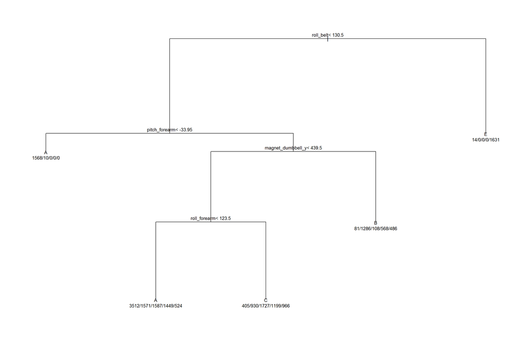

The accuracy of the default method is 53.3% and the error is 46.7%.

A tuning option for Trees in order to increase accuracy, is increasing the number of splits. One way of doing this, is by increasing the **tuneLength** parameter. Following there is an example increasing the parameter to 50. There is a considerable increase in the accuracy. However, the complexity increases and the interpretability is reduced.

```
## CART
##
## 19622 samples
##    51 predictor
##     5 classes: 'A', 'B', 'C', 'D', 'E'
##
## No pre-processing
## Resampling: Cross-Validated (10 fold, repeated 5 times)
## Summary of sample sizes: 17659, 17660, 17659, 17660, 17659, 17660, ...
## Resampling results across tuning parameters:
##
##   cp           Accuracy   Kappa
##   0.001851588  0.9066755  0.88193042
##   0.001922803  0.9046983  0.87943020
##   0.002421308  0.8947806  0.86690137
##   0.002492522  0.8920694  0.86349015
##   0.002563737  0.8892460  0.85993170
##   0.002634952  0.8873908  0.85759139
##   0.002777382  0.8816830  0.85039296
##   0.002884205  0.8793998  0.84752327
##   0.002991027  0.8767703  0.84418833
##   0.003062242  0.8753026  0.84233834
##   0.003347102  0.8712461  0.83721167
##   0.003537008  0.8666596  0.83141822
##   0.003560746  0.8658543  0.83039888
##   0.003703176  0.8636937  0.82766384
##   0.003916821  0.8597694  0.82268893
##   0.004201681  0.8557130  0.81755880
##   0.004415325  0.8538272  0.81517130
##   0.004664578  0.8487619  0.80872713
##   0.004842615  0.8446743  0.80351532
##   0.005127475  0.8410763  0.79890911
##   0.006053269  0.8250230  0.77833390
##   0.006124484  0.8227196  0.77536512
##   0.006195699  0.8197533  0.77157865
##   0.006409343  0.8141569  0.76443926
##   0.007050278  0.8032308  0.75024903
##   0.007192708  0.8017631  0.74832572
##   0.007335137  0.7996430  0.74547859
##   0.007548782  0.7943834  0.73864695
```

[output cut: 10 more lines]

```
##   0.013388406  0.7009669  0.62161065
##   0.013459621  0.6999072  0.62030930
##   0.016806723  0.6753132  0.58972524
##   0.019228030  0.6656083  0.57777942
##   0.020509899  0.6525325  0.56153355
##   0.021506908  0.6480480  0.55584903
##   0.022575132  0.6358672  0.54045842
##   0.023714571  0.6108851  0.50854002
##   0.035678678  0.5655893  0.44972520
##   0.038918957  0.5342241  0.40083617
##   0.059986707  0.4137115  0.20458404
##   0.115154536  0.3248717  0.06172254
##
## Accuracy was used to select the optimal model using the largest value.
## The final value used for the model was cp = 0.001851588.
```

The accuracy of the tuned method is 90.7% and the error is 9.3%.

### Random Forest

Random Forest is one of the highest accuracy prediction methods. However, the drawbacks are that is less interpretable and much slower to train. Following there is the summary of the final model:

```
## Random Forest
##
## 19622 samples
##    51 predictor
##     5 classes: 'A', 'B', 'C', 'D', 'E'
##
## No pre-processing
## Resampling: Cross-Validated (10 fold, repeated 3 times)
## Summary of sample sizes: 17660, 17658, 17659, 17659, 17660, 17661, ...
## Resampling results across tuning parameters:
##
##   mtry  Accuracy   Kappa
##    2    0.9967723  0.9959171
##   26    0.9985731  0.9981952
##   51    0.9967892  0.9959385
##
## Accuracy was used to select the optimal model using the largest value.
## The final value used for the model was mtry = 26.
```

Accuracy is almost 100%. The error is lower than 0.2%.

### Method selection

Despite training velocity is much slower and it is less interpretable than Trees, due to highest accuracy, the method selected for prediction was **Random Forest**. However, if models had to be trained again, I’d use tuned Trees, sacrificing some accuracy for speed.

## Prediction

Using Random Forest trained algorithm, following there is the prediction for the testing data set:

```
##  [1] B A B A A E D B A A B C B A E E A B B B
## Levels: A B C D E
```